# Tendencias temporales de las personas que declararon cambiar de residencia como medida de protección contra la delincuencia

#### Promedio de 3 años

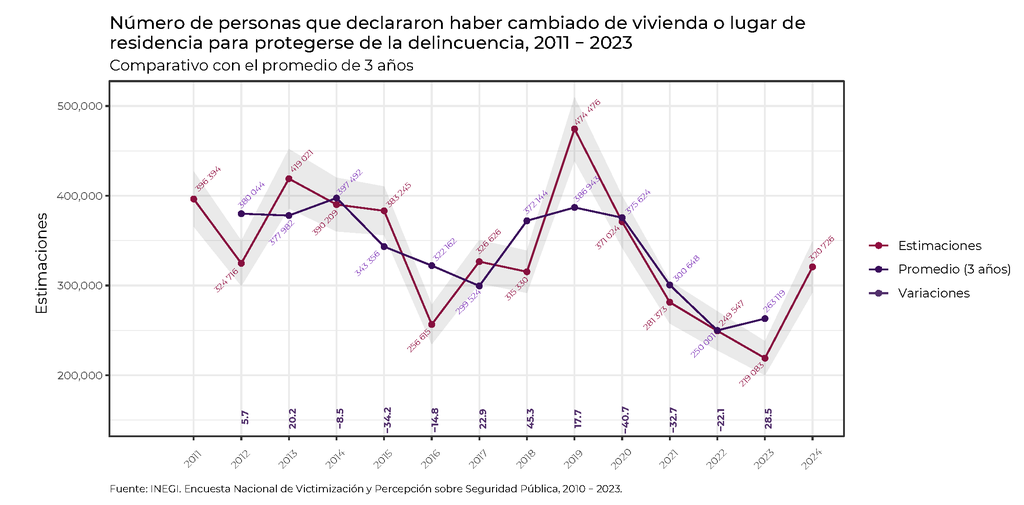

```r
p <- Personas %>%
      ggplot(aes(x = Año, y = Est)) +
       geom_point(aes(color = "LINE1")) +
        geom_line(aes(color = "LINE1")) +
        geom_ribbon(aes(ymin = CI, ymax = CS),
                    linetype = 2,
                    alpha = 0.1) +
        geom_text_repel(aes(label = format(Est, big.mark = " ")),
                        position = position_jitter(seed = 123),
                        size = 2,
                        color = "#900C3F",
                        angle = 45,
                        force = 0.7,
                        segment.linetype = 1,
                        direction = c("both"),
                        family = "Montserrat",
                          max.overlaps = 2) +
         ## Promedio de 2 años
          geom_point(aes(x = Año - 1, y = P.3años, color = "LINE2")) +
          geom_line(aes(x = Año - 1, y = P.3años, color = "LINE2")) +
          geom_text_repel(aes(x = Año - 1, y = P.3años, label = format(P.3años, big.mark = " ")),
                          position = position_jitter(seed = 123),
                          size = 2,
                          color = "#7e33b8",
                          angle = 45,
                          force = 0.7,
                          segment.linetype = 1,
                          direction = c("both"),
                          family = "Montserrat",
                          max.overlaps = 2) +
           ## Variaciones
           geom_text(data = Personas %>% slice(3:14),
                     aes(x = Año - 1,
                         y = 150000,
                         label = format(Var.3años, digits = 2, nsmall = 1),
                         color = "LINE3"),
                     size = 2.5,
                     vjust = 1,
                     fontface = "bold",
                     angle = 90,
                     family = "Montserrat"
                       ) +
           theme_bw() +
            theme(text = element_text(family = "Montserrat"),
                  axis.text.y = element_text(size = 8),
                  axis.text.x = element_text(size = 6, angle = 45, vjust = 0),
                  plot.caption = element_text(size = 7, hjust = 0, vjust = -1.5, family = "Montserrat"),
            ) +
             scale_y_continuous(labels = scales::comma) +
             scale_x_discrete(limits = seq(2011, 2024, 1)) +
             scale_color_manual(labels = c("Estimaciones",
                                           "Promedio (3 años)",
                                           "Variaciones"),
                                values = c("LINE1" = "#900C3F",
                                           "LINE2" = "#3a0d5c",
                                           "LINE3" = "#52306c")
                                ) +
             labs(title = stringr::str_wrap("Número de personas que declararon haber cambiado de vivienda o lugar de residencia para protegerse de la delincuencia, 2011 - 2023", 80),
                  subtitle = "Comparativo con el promedio de 3 años",
                  x = "",
                  y = "Estimaciones",
                  color = "",
                  caption = expression(paste("Fuente: INEGI. Encuesta Nacional de Victimización y Percepción sobre Seguridad Pública, 2010 - 2023.")))

p

path = paste0(here::here(),"/Output/ENVIPE_Comparativo de 3 años.pdf")
ggexport(list = p, width = 10, height = 5, dpi = 400, filename = path)
```

#### Promedio de 4 años

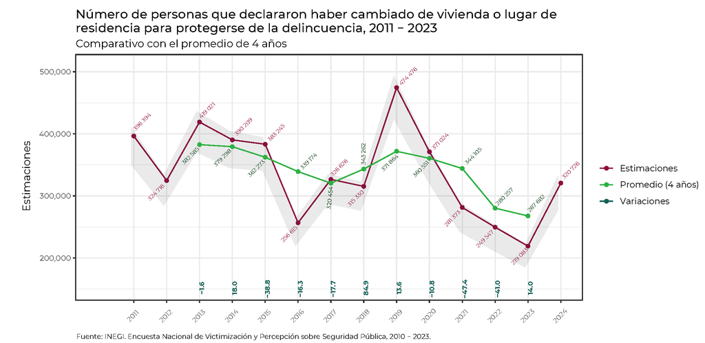

```r
p <- Personas %>%
      ggplot(aes(x = Año, y = Est)) +
       geom_point(aes(color = "LINE1")) +
        geom_line(aes(color = "LINE1")) +
        geom_ribbon(aes(ymin = CI, ymax = CS),
                    linetype = 2,
                    alpha = 0.1) +
        geom_text_repel(aes(label = format(Est, big.mark = " ")),
                        position = position_jitter(seed = 123),
                        size = 2,
                        color = "#900C3F",
                        angle = 45,
                        force = 0.7,
                        segment.linetype = 1,
                        direction = c("both"),
                        family = "Montserrat",
                          max.overlaps = 2) +
         ## Promedio de 2 años
          geom_point(aes(x = Año - 1, y = P.4años, color = "LINE2")) +
          geom_line(aes(x = Año - 1, y = P.4años, color = "LINE2")) +
          geom_text_repel(aes(x = Año - 1, y = P.4años, label = format(P.4años, big.mark = " ")),
                          position = position_jitter(seed = 123),
                          size = 2,
                          color = "#02360d",
                          angle = 45,
                          force = 0.7,
                          segment.linetype = 1,
                          direction = c("both"),
                          family = "Montserrat",
                          max.overlaps = 2) +
           ## Variaciones
           geom_text(data = Personas %>% slice(4:14),
                     aes(x = Año - 1,
                         y = 150000,
                         label = format(Var.4años, digits = 2, nsmall = 1),
                         color = "LINE3"),
                     size = 2.5,
                     vjust = 1,
                     fontface = "bold",
                     angle = 90,
                     family = "Montserrat"
                       ) +
           theme_bw() +
            theme(text = element_text(family = "Montserrat"),
                  axis.text.y = element_text(size = 8),
                  axis.text.x = element_text(size = 6, angle = 45, vjust = 0),
                  plot.caption = element_text(size = 7, hjust = 0, vjust = -1.5, family = "Montserrat"),
            ) +
             scale_y_continuous(labels = scales::comma) +
             scale_x_discrete(limits = seq(2011, 2024, 1)) +
             scale_color_manual(labels = c("Estimaciones",
                                           "Promedio (4 años)",
                                           "Variaciones"),
                                values = c("LINE1" = "#900C3F",
                                           "LINE2" = "#2cb141",
                                           "LINE3" = "#146157")
                                ) +
             labs(title = stringr::str_wrap("Número de personas que declararon haber cambiado de vivienda o lugar de residencia para protegerse de la delincuencia, 2011 - 2023", 80),
                  subtitle = "Comparativo con el promedio de 4 años",
                  x = "",
                  y = "Estimaciones",
                  color = "",
                  caption = expression(paste("Fuente: INEGI. Encuesta Nacional de Victimización y Percepción sobre Seguridad Pública, 2010 - 2023.")))

p

path = paste0(here::here(),"/Output/ENVIPE_Comparativo de 4 años.pdf")
ggexport(list = p, width = 10, height = 5, dpi = 400, filename = path)
```

### Comparativos a nivel Regional

```r
Region <- read_xlsx(paste0(here::here(), "/Bases/MC_ENVIPE 2011 - 2024.xlsx"),
                    sheet = "Tablas",
                    range = "C39:Q45",
                    col_names = TRUE)
```

Durante 2023, para protegerse de la delincuencia, ¿en este hogar se realizó algún tipo de medida como… cambiarse de vivienda o lugar de residencia?

Personas que cambiaron de vivienda o lugar de residencia por Región

| Región | 2011 | 2012 | 2013 | 2014 | 2015 | 2016 | 2017 | 2018 | 2019 | 2020 | 2021 | 2022 | 2023 | 2024 |
| --- | --- | --- | --- | --- | --- | --- | --- | --- | --- | --- | --- | --- | --- | --- |
| Centro | 108 514 | 79 371 | 156 416 | 144 266 | 117 252 | 91 159 | 109 010 | 103 490 | 194 670 | 146 815 | 97 589 | 66 561 | 57 438 | 125 481 |
| Noreste | 51 370 | 70 083 | 51 877 | 62 221 | 55 222 | 33 608 | 39 608 | 31 247 | 44 202 | 40 985 | 44 740 | 29 855 | 37 262 | 38 530 |
| Noroeste | 68 219 | 42 268 | 50 386 | 43 135 | 51 529 | 25 380 | 42 651 | 39 165 | 54 791 | 33 752 | 27 343 | 20 659 | 24 027 | 32 690 |
| Occidente | 95 128 | 74 380 | 106 568 | 88 300 | 103 841 | 62 243 | 83 739 | 84 189 | 120 365 | 103 174 | 73 131 | 95 113 | 59 822 | 75 096 |
| Sureste | 73 163 | 58 614 | 53 774 | 52 287 | 55 401 | 44 225 | 51 618 | 57 239 | 60 448 | 46 298 | 38 570 | 37 359 | 40 534 | 48 929 |
| Total | 396 394 | 324 716 | 419 021 | 390 209 | 383 245 | 256 615 | 326 626 | 315 330 | 474 476 | 371 024 | 281 373 | 249 547 | 219 083 | 320 726 |

Fuente: INEGI. Encuesta Nacional de Victimización y Percepción sobre Seguridad Pública, 2010 - 2023.

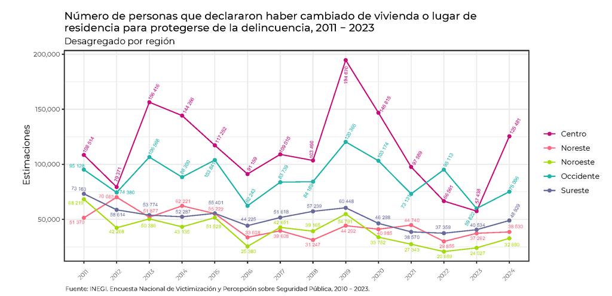

```r
require(reshape2)
require(Hmisc)

tabla <- Region %>%
          melt() %>%
           filter(Región %nin% "Total")

p <- tabla %>%
      ggplot(aes(x = variable, y = value)) +
       geom_point(aes(color = Región)) +
        geom_line(aes(color = Región, group = Región)) +
         geom_text(data = tabla,
                   aes(x = variable,
                       y = value,
                       label = format(value, big.mark = " "),
                       color = Región,
                       group = Región),
                   size = 2,
                   angle = 60
                   ) +
           theme_bw() +
            theme(text = element_text(family = "Montserrat"),
                  axis.text.y = element_text(size = 8),
                  axis.text.x = element_text(size = 6, angle = 45, vjust = 0),
                  plot.caption = element_text(size = 7, hjust = 0, vjust = -1.5, family = "Montserrat"),
            ) +
             scale_y_continuous(labels = scales::comma) +
             scale_color_manual(values = colorRampPalette(LaCroixColoR::lacroix_palette("PassionFruit", n = 50, type = "continuous"))(6)
                                ) +
             labs(title = stringr::str_wrap("Número de personas que declararon haber cambiado de vivienda o lugar de residencia para protegerse de la delincuencia, 2011 - 2023", 80),
                  subtitle = "Desagregado por región",
                  x = "",
                  y = "Estimaciones",
                  color = "",
                  caption = expression(paste("Fuente: INEGI. Encuesta Nacional de Victimización y Percepción sobre Seguridad Pública, 2010 - 2023.")))

p

path = paste0(here::here(),"/Output/ENVIPE_Region.pdf")
ggexport(list = p, width = 10, height = 5, dpi = 400, filename = path)
```

### Comparativos a nivel Dominio

```r
Dominio <- read_xlsx(paste0(here::here(), "/Bases/MC_ENVIPE 2011 - 2024.xlsx"),
                     sheet = "Tablas",
                     range = "C47:Q51",
                     col_names = TRUE)
```

Durante 2023, para protegerse de la delincuencia, ¿en este hogar se realizó algún tipo de medida como… cambiarse de vivienda o lugar de residencia?

Personas que cambiaron de vivienda o lugar de residencia por Dominio

| Dominio | 2011 | 2012 | 2013 | 2014 | 2015 | 2016 | 2017 | 2018 | 2019 | 2020 | 2021 | 2022 | 2023 | 2024 |
| --- | --- | --- | --- | --- | --- | --- | --- | --- | --- | --- | --- | --- | --- | --- |
| Complemento urbano | 71 068 | 48 015 | 70 509 | 69 004 | 67 213 | 47 174 | 58 360 | 55 991 | 73 290 | 72 819 | 43 160 | 48 576 | 50 393 | 54 660 |
| Rural | 40 346 | 21 909 | 30 940 | 29 125 | 46 680 | 21 025 | 28 082 | 25 940 | 38 755 | 35 395 | 30 153 | 27 272 | 24 437 | 28 747 |
| Urbano | 129 719 | 254 792 | 317 572 | 292 080 | 269 352 | 188 416 | 240 184 | 233 399 | 362 431 | 262 810 | 208 060 | 173 699 | 144 253 | 237 319 |
| Total | 396 394 | 324 716 | 419 021 | 390 209 | 383 245 | 256 615 | 326 626 | 315 330 | 474 476 | 371 024 | 281 373 | 249 547 | 219 083 | 320 726 |

Fuente: INEGI. Encuesta Nacional de Victimización y Percepción sobre Seguridad Pública, 2010 - 2023.

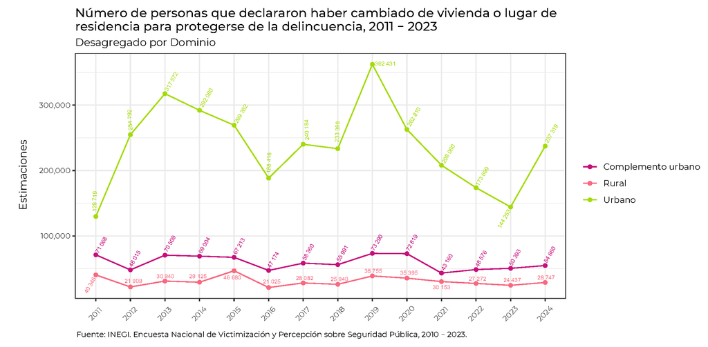

```r
require(reshape2)
require(Hmisc)

tabla <- Dominio %>%
          melt() %>%
           filter(Dominio %nin% "Total")

p <- tabla %>%
      ggplot(aes(x = variable, y = value)) +
       geom_point(aes(color = Dominio)) +
        geom_line(aes(color = Dominio, group = Dominio)) +
         geom_text(data = tabla,
                   aes(x = variable,
                       y = value,
                       label = format(value, big.mark = " "),
                       color = Dominio,
                       group = Dominio),
                   size = 2,
                   angle = 60
                   ) +
           theme_bw() +
            theme(text = element_text(family = "Montserrat"),
                  axis.text.y = element_text(size = 8),
                  axis.text.x = element_text(size = 6, angle = 45, vjust = 0),
                  plot.caption = element_text(size = 7, hjust = 0, vjust = -1.5, family = "Montserrat"),
            ) +
             scale_y_continuous(labels = scales::comma) +
             scale_color_manual(values = colorRampPalette(LaCroixColoR::lacroix_palette("PassionFruit", n = 50, type = "continuous"))(6)
                                ) +
             labs(title = stringr::str_wrap("Número de personas que declararon haber cambiado de vivienda o lugar de residencia para protegerse de la delincuencia, 2011 - 2023", 80),
                  subtitle = "Desagregado por Dominio",
                  x = "",
                  y = "Estimaciones",
                  color = "",
                  caption = expression(paste("Fuente: INEGI. Encuesta Nacional de Victimización y Percepción sobre Seguridad Pública, 2010 - 2023.")))

p

path = paste0(here::here(),"/Output/ENVIPE_Dominio.pdf")
ggexport(list = p, width = 10, height = 5, dpi = 400, filename = path)
```

## Hogares

AP4_11_10 4.11 Durante 2023, para protegerse de la delincuencia, ¿en este hogar se realizó algún tipo de medida como… cambiarse de vivienda o lugar de residencia?

```r
Hogares <- read_xlsx(paste0(here::here(), "/Bases/MC_ENVIPE 2011 - 2024.xlsx"),
                     sheet = "Promedios",
                     range = "N5:W19",
                     col_names = TRUE)
```

Durante 2023, para protegerse de la delincuencia, ¿en este hogar se realizó algún tipo de medida como… cambiarse de vivienda o lugar de residencia?

Total de personas en los hogares que cambiaron de vivienda o lugar de residencia

| Año | **Estimación** | CI (5%) | CS (95%) | Promedio (2 años) | Promedio (3 años) | Promedio (4 años) | Variación (2 años) | Variación (3 años) | Variación (4 años) |
| --- | --- | --- | --- | --- | --- | --- | --- | --- | --- |
| 2011 | 1 464 562 | 1 338 186 | 1 590 938 | NA | NA | NA | NA | NA | NA |
| 2012 | 1 156 070 | 1 058 434 | 1 253 706 | 1 310 316 | NA | NA | −21.0638 | NA | NA |
| 2013 | 1 549 090 | 1 408 672 | 1 689 508 | 1 352 580 | 1 389 907 | NA | 33.9962 | 5.7716 | NA |
| 2014 | 1 419 344 | 1 299 484 | 1 539 204 | 1 484 217 | 1 374 835 | 1 397 267 | −8.3756 | 22.7732 | −3.0875 |
| 2015 | 1 397 419 | 1 287 990 | 1 506 848 | 1 408 382 | 1 455 284 | 1 380 481 | −1.5447 | −9.7910 | 20.8767 |
| 2016 | 915 893 | 829 258 | 1 002 528 | 1 156 656 | 1 244 219 | 1 320 437 | −34.4582 | −35.4707 | −40.8754 |
| 2017 | 1 155 518 | 1 061 092 | 1 249 944 | 1 035 706 | 1 156 277 | 1 222 044 | 26.1630 | −17.3106 | −18.5879 |
| 2018 | 1 133 041 | 1 033 782 | 1 232 300 | 1 144 280 | 1 068 151 | 1 150 468 | −1.9452 | 23.7089 | −18.9190 |
| 2019 | 1 723 857 | 1 580 517 | 1 867 197 | 1 428 449 | 1 337 472 | 1 232 077 | 52.1443 | 49.1848 | 88.2160 |
| 2020 | 1 251 825 | 1 146 125 | 1 357 525 | 1 487 841 | 1 369 574 | 1 316 060 | −27.3823 | 10.4836 | 8.3345 |
| 2021 | 911 914 | 830 006 | 993 822 | 1 081 870 | 1 295 865 | 1 255 159 | −27.1532 | −47.1004 | −19.5162 |
| 2022 | 831 490 | 753 014 | 909 966 | 871 702 | 998 410 | 1 179 772 | −8.8193 | −33.5778 | −51.7657 |
| 2023 | 699 120 | 631 936 | 766 304 | 765 305 | 814 175 | 923 587 | −15.9196 | −23.3349 | −44.1519 |
| 2024 | 1 006 810 | 910 233 | 1 103 387 | 852 965 | 845 807 | 862 334 | 44.0110 | 21.0850 | 10.4062 |

Fuente: INEGI. Encuesta Nacional de Victimización y Percepción sobre Seguridad Pública, 2010 - 2023.

### Comparativos a nivel Nacional

#### Promedio de 2 años

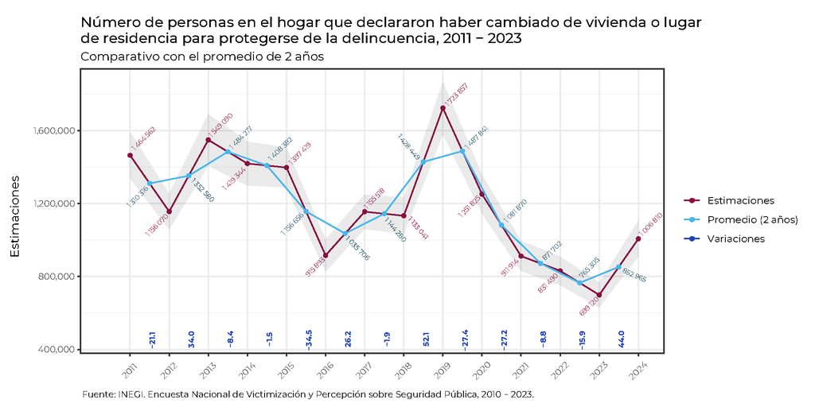

```r
p <- Hogares %>%
      ggplot(aes(x = Año, y = Est)) +
       geom_point(aes(color = "LINE1")) +
        geom_line(aes(color = "LINE1")) +
        geom_ribbon(aes(ymin = CI, ymax = CS),
                    linetype = 2,
                    alpha = 0.1) +
        geom_text_repel(aes(label = format(Est, big.mark = " ")),
                        position = position_jitter(seed = 123),
                        size = 2,
                        color = "#900C3F",
                        angle = 45,
                        force = 0.7,
                        segment.linetype = 1,
                        direction = c("both"),
                        family = "Montserrat",
                          max.overlaps = 2) +
         ## Promedio de 2 años
          geom_point(aes(x = Año - 0.5, y = P.2años, color = "LINE2")) +
          geom_line(aes(x = Año - 0.5, y = P.2años, color = "LINE2")) +
          geom_text_repel(aes(x = Año - 0.5, y = P.2años, label = format(P.2años, big.mark = " ")),
                          position = position_jitter(seed = 123),
                          size = 2,
                          color = "#194c65",
                          angle = 45,
                          force = 0.7,
                          segment.linetype = 1,
                          direction = c("both"),
                          family = "Montserrat",
                          max.overlaps = 2) +
           ## Variaciones
           geom_text(aes(x = Año - 0.5,
                         y = 450000,
                         label = format(Var.2años, digits = 2, nsmall = 1),
                         color = "LINE3"),
                     size = 2.5,
                     vjust = 1,
                     fontface = "bold",
                     angle = 90,
                     family = "Montserrat"
                       ) +
           theme_bw() +
            theme(text = element_text(family = "Montserrat"),
                  axis.text.y = element_text(size = 8),
                  axis.text.x = element_text(size = 6, angle = 45, vjust = 0),
                  plot.caption = element_text(size = 7, hjust = 0, vjust = -1.5, family = "Montserrat"),
            ) +
             scale_y_continuous(labels = scales::comma) +
             scale_x_discrete(limits = seq(2011, 2024, 1)) +
             scale_color_manual(labels = c("Estimaciones",
                                           "Promedio (2 años)",
                                           "Variaciones"),
                                values = c("LINE1" = "#900C3F",
                                           "LINE2" = "#48b6ec",
                                           "LINE3" = "#1f42c1")
                                ) +
             labs(title = stringr::str_wrap("Número de personas en el hogar que declararon haber cambiado de vivienda o lugar de residencia para protegerse de la delincuencia, 2011 - 2023", 80),
                  subtitle = "Comparativo con el promedio de 2 años",
                  x = "",
                  y = "Estimaciones",
                  color = "",
                  caption = expression(paste("Fuente: INEGI. Encuesta Nacional de Victimización y Percepción sobre Seguridad Pública, 2010 - 2023.")))

p

path = paste0(here::here(),"/Output/ENVIPE_Comparativo de 2 años_Hogar.pdf")
ggexport(list = p, width = 10, height = 5, dpi = 400, filename = path)
```

#### Promedio de 3 años

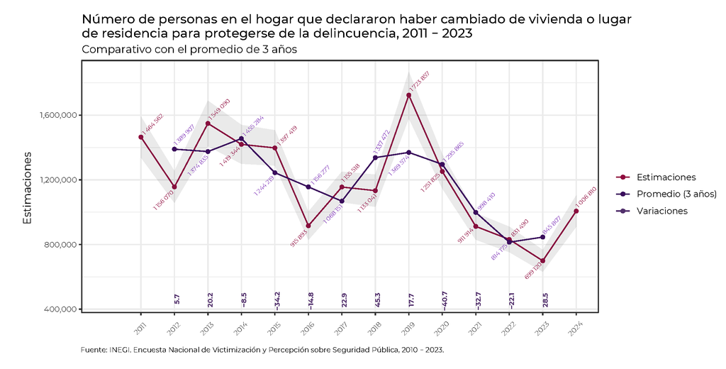

```r
p <- Hogares %>%
      ggplot(aes(x = Año, y = Est)) +
       geom_point(aes(color = "LINE1")) +
        geom_line(aes(color = "LINE1")) +
        geom_ribbon(aes(ymin = CI, ymax = CS),
                    linetype = 2,
                    alpha = 0.1) +
        geom_text_repel(aes(label = format(Est, big.mark = " ")),
                        position = position_jitter(seed = 123),
                        size = 2,
                        color = "#900C3F",
                        angle = 45,
                        force = 0.7,
                        segment.linetype = 1,
                        direction = c("both"),
                        family = "Montserrat",
                          max.overlaps = 2) +
         ## Promedio de 2 años
          geom_point(aes(x = Año - 1, y = P.3años, color = "LINE2")) +
          geom_line(aes(x = Año - 1, y = P.3años, color = "LINE2")) +
          geom_text_repel(aes(x = Año - 1, y = P.3años, label = format(P.3años, big.mark = " ")),
                          position = position_jitter(seed = 123),
                          size = 2,
                          color = "#7e33b8",
                          angle = 45,
                          force = 0.7,
                          segment.linetype = 1,
                          direction = c("both"),
                          family = "Montserrat",
                          max.overlaps = 2) +
           ## Variaciones
           geom_text(data = Personas %>% slice(3:14),
                     aes(x = Año - 1,
                         y = 450000,
                         label = format(Var.3años, digits = 2, nsmall = 1),
                         color = "LINE3"),
                     size = 2.5,
                     vjust = 1,
                     fontface = "bold",
                     angle = 90,
                     family = "Montserrat"
                       ) +
           theme_bw() +
            theme(text = element_text(family = "Montserrat"),
                  axis.text.y = element_text(size = 8),
                  axis.text.x = element_text(size = 6, angle = 45, vjust = 0),
                  plot.caption = element_text(size = 7, hjust = 0, vjust = -1.5, family = "Montserrat"),
            ) +
             scale_y_continuous(labels = scales::comma) +
             scale_x_discrete(limits = seq(2011, 2024, 1)) +
             scale_color_manual(labels = c("Estimaciones",
                                           "Promedio (3 años)",
                                           "Variaciones"),
                                values = c("LINE1" = "#900C3F",
                                           "LINE2" = "#3a0d5c",
                                           "LINE3" = "#52306c")
                                ) +
             labs(title = stringr::str_wrap("Número de personas en el hogar que declararon haber cambiado de vivienda o lugar de residencia para protegerse de la delincuencia, 2011 - 2023", 80),
                  subtitle = "Comparativo con el promedio de 3 años",
                  x = "",
                  y = "Estimaciones",
                  color = "",
                  caption = expression(paste("Fuente: INEGI. Encuesta Nacional de Victimización y Percepción sobre Seguridad Pública, 2010 - 2023.")))

p

path = paste0(here::here(),"/Output/ENVIPE_Comparativo de 3 años_Hogar.pdf")
ggexport(list = p, width = 10, height = 5, dpi = 400, filename = path)
```

#### Promedio de 4 años

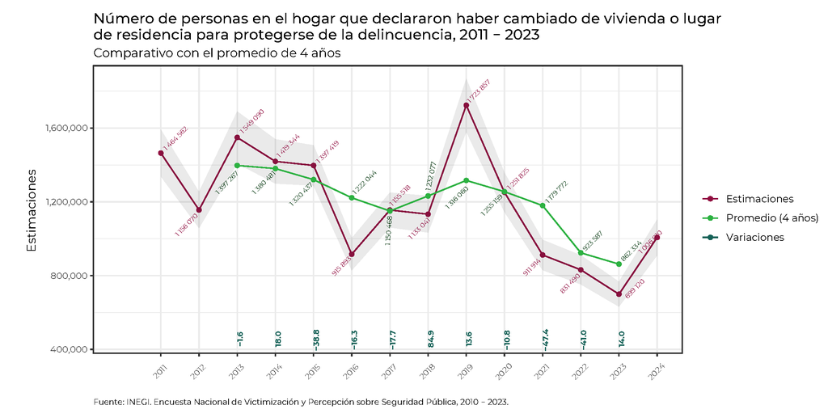

```r
p <- Hogares %>%
      ggplot(aes(x = Año, y = Est)) +
       geom_point(aes(color = "LINE1")) +
        geom_line(aes(color = "LINE1")) +
        geom_ribbon(aes(ymin = CI, ymax = CS),
                    linetype = 2,
                    alpha = 0.1) +
        geom_text_repel(aes(label = format(Est, big.mark = " ")),
                        position = position_jitter(seed = 123),
                        size = 2,
                        color = "#900C3F",
                        angle = 45,
                        force = 0.7,
                        segment.linetype = 1,
                        direction = c("both"),
                        family = "Montserrat",
                          max.overlaps = 2) +
         ## Promedio de 2 años
          geom_point(aes(x = Año - 1, y = P.4años, color = "LINE2")) +
          geom_line(aes(x = Año - 1, y = P.4años, color = "LINE2")) +
          geom_text_repel(aes(x = Año - 1, y = P.4años, label = format(P.4años, big.mark = " ")),
                          position = position_jitter(seed = 123),
                          size = 2,
                          color = "#02360d",
                          angle = 45,
                          force = 0.7,
                          segment.linetype = 1,
                          direction = c("both"),
                          family = "Montserrat",
                          max.overlaps = 2) +
           ## Variaciones
           geom_text(data = Personas %>% slice(4:14),
                     aes(x = Año - 1,
                         y = 450000,
                         label = format(Var.4años, digits = 2, nsmall = 1),
                         color = "LINE3"),
                     size = 2.5,
                     vjust = 1,
                     fontface = "bold",
                     angle = 90,
                     family = "Montserrat"
                       ) +
           theme_bw() +
            theme(text = element_text(family = "Montserrat"),
                  axis.text.y = element_text(size = 8),
                  axis.text.x = element_text(size = 6, angle = 45, vjust = 0),
                  plot.caption = element_text(size = 7, hjust = 0, vjust = -1.5, family = "Montserrat"),
            ) +
             scale_y_continuous(labels = scales::comma) +
             scale_x_discrete(limits = seq(2011, 2024, 1)) +
             scale_color_manual(labels = c("Estimaciones",
                                           "Promedio (4 años)",
                                           "Variaciones"),
                                values = c("LINE1" = "#900C3F",
                                           "LINE2" = "#2cb141",
                                           "LINE3" = "#146157")
                                ) +
             labs(title = stringr::str_wrap("Número de personas en el hogar que declararon haber cambiado de vivienda o lugar de residencia para protegerse de la delincuencia, 2011 - 2023", 80),
                  subtitle = "Comparativo con el promedio de 4 años",
                  x = "",
                  y = "Estimaciones",
                  color = "",
                  caption = expression(paste("Fuente: INEGI. Encuesta Nacional de Victimización y Percepción sobre Seguridad Pública, 2010 - 2023.")))

p

path = paste0(here::here(),"/Output/ENVIPE_Comparativo de 4 años_Hogar.pdf")
ggexport(list = p, width = 10, height = 5, dpi = 400, filename = path)
```

### Comparativos a nivel Regional

```r
Region_Hogar <- read_xlsx(paste0(here::here(), "/Bases/MC_ENVIPE 2011 - 2024.xlsx"),
                          sheet = "Tablas",
                          range = "T39:AH45",
                          col_names = TRUE)
```

Durante 2023, para protegerse de la delincuencia, ¿en este hogar se realizó algún tipo de medida como… cambiarse de vivienda o lugar de residencia?

Total de personas que cambiaron de vivienda o lugar de residencia por Región

| Región | 2011 | 2012 | 2013 | 2014 | 2015 | 2016 | 2017 | 2018 | 2019 | 2020 | 2021 | 2022 | 2023 | 2024 |
| --- | --- | --- | --- | --- | --- | --- | --- | --- | --- | --- | --- | --- | --- | --- |
| Centro | 390 402 | 280 168 | 607 407 | 541 129 | 430 632 | 327 884 | 403 926 | 385 386 | 719 823 | 493 026 | 297 301 | 222 157 | 177 982 | 375 894 |
| Noreste | 196 543 | 269 784 | 192 051 | 219 906 | 194 741 | 116 571 | 128 696 | 113 754 | 153 684 | 145 705 | 149 328 | 96 625 | 121 448 | 121 178 |
| Noroeste | 251 743 | 137 262 | 189 225 | 162 962 | 185 441 | 88 804 | 142 535 | 140 882 | 179 877 | 119 919 | 89 070 | 69 222 | 75 613 | 113 788 |
| Occidente | 349 254 | 272 525 | 377 893 | 312 255 | 386 158 | 231 384 | 314 358 | 291 327 | 458 404 | 342 790 | 254 447 | 318 300 | 190 793 | 242 232 |
| Sureste | 276 620 | 196 331 | 182 514 | 183 092 | 200 447 | 151 250 | 166 003 | 201 692 | 212 069 | 150 385 | 121 768 | 125 186 | 133 284 | 153 718 |
| Total | 1 464 562 | 1 156 070 | 1 549 090 | 1 419 344 | 1 397 419 | 915 893 | 1 155 518 | 1 133 041 | 1 723 857 | 1 251 825 | 911 914 | 831 490 | 699 120 | 1 006 810 |

Fuente: INEGI. Encuesta Nacional de Victimización y Percepción sobre Seguridad Pública, 2010 - 2023.

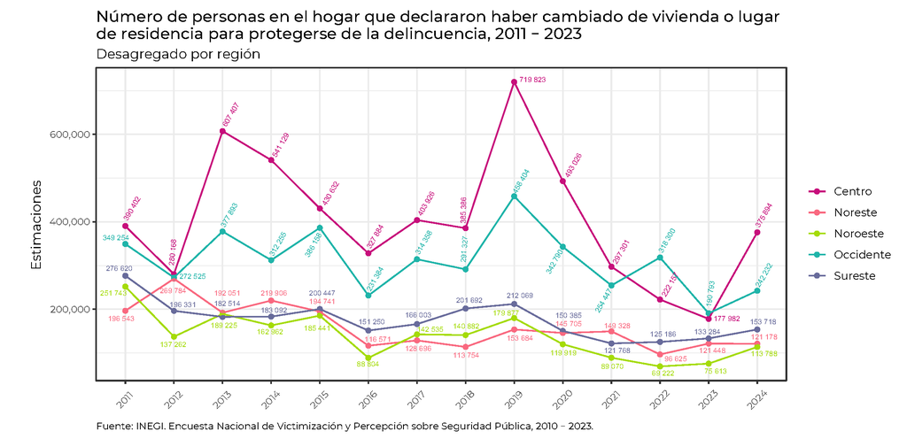

```r
require(reshape2)
require(Hmisc)

tabla <- Region_Hogar %>%
          melt() %>%
           filter(Región %nin% "Total")

p <- tabla %>%
      ggplot(aes(x = variable, y = value)) +
       geom_point(aes(color = Región)) +
        geom_line(aes(color = Región, group = Región)) +
         geom_text(data = tabla,
                   aes(x = variable,
                       y = value,
                       label = format(value, big.mark = " "),
                       color = Región,
                       group = Región),
                   size = 2,
                   angle = 60
                   ) +
           theme_bw() +
            theme(text = element_text(family = "Montserrat"),
                  axis.text.y = element_text(size = 8),
                  axis.text.x = element_text(size = 6, angle = 45, vjust = 0),
                  plot.caption = element_text(size = 7, hjust = 0, vjust = -1.5, family = "Montserrat"),
            ) +
             scale_y_continuous(labels = scales::comma) +
             scale_color_manual(values = colorRampPalette(LaCroixColoR::lacroix_palette("PassionFruit", n = 50, type = "continuous"))(6)
                                ) +
             labs(title = stringr::str_wrap("Número de personas en el hogar que declararon haber cambiado de vivienda o lugar de residencia para protegerse de la delincuencia, 2011 - 2023", 80),
                  subtitle = "Desagregado por región",
                  x = "",
                  y = "Estimaciones",
                  color = "",
                  caption = expression(paste("Fuente: INEGI. Encuesta Nacional de Victimización y Percepción sobre Seguridad Pública, 2010 - 2023.")))

p

path = paste0(here::here(),"/Output/ENVIPE_Region_Hogar.pdf")
ggexport(list = p, width = 10, height = 5, dpi = 400, filename = path)
```

### Comparativos a nivel Dominio

```r
Dominio_Hogar <- read_xlsx(paste0(here::here(), "/Bases/MC_ENVIPE 2011 - 2024.xlsx"),
                           sheet = "Tablas",
                           range = "T47:AH51",
                           col_names = TRUE)
```

Durante 2023, para protegerse de la delincuencia, ¿en este hogar se realizó algún tipo de medida como… cambiarse de vivienda o lugar de residencia?

Total de personas que cambiaron de vivienda o lugar de residencia por Dominio

| Dominio | 2011 | 2012 | 2013 | 2014 | 2015 | 2016 | 2017 | 2018 | 2019 | 2020 | 2021 | 2022 | 2023 | 2024 |
| --- | --- | --- | --- | --- | --- | --- | --- | --- | --- | --- | --- | --- | --- | --- |
| Complemento urbano | 278 995 | 159 850 | 274 059 | 254 593 | 255 631 | 173 044 | 218 354 | 200 104 | 287 467 | 255 238 | 155 905 | 161 677 | 179 301 | 166 819 |
| Rural | 152 438 | 86 020 | 107 964 | 131 084 | 185 438 | 79 640 | 115 657 | 105 076 | 149 621 | 132 327 | 114 349 | 107 256 | 73 345 | 92 786 |
| Urbano | 464 317 | 910 200 | 1 167 067 | 1 033 667 | 956 350 | 663 209 | 821 507 | 827 861 | 1 286 769 | 864 260 | 641 660 | 562 557 | 446 474 | 747 205 |
| Total | 1 464 562 | 1 156 070 | 1 549 090 | 1 419 344 | 1 397 419 | 915 893 | 1 155 518 | 1 133 041 | 1 723 857 | 1 251 825 | 911 914 | 831 490 | 699 120 | 1 006 810 |

Fuente: INEGI. Encuesta Nacional de Victimización y Percepción sobre Seguridad Pública, 2010 - 2023.

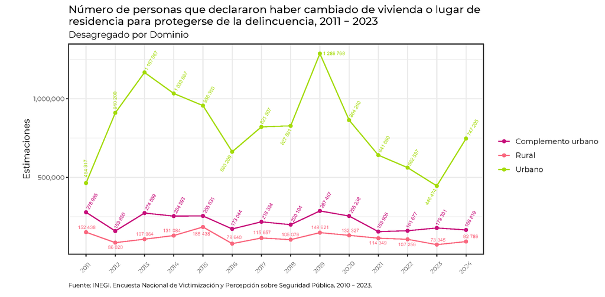

```r
require(reshape2)
require(Hmisc)

tabla <- Dominio_Hogar %>%
          melt() %>%
           filter(Dominio %nin% "Total")

p <- tabla %>%
      ggplot(aes(x = variable, y = value)) +
       geom_point(aes(color = Dominio)) +
        geom_line(aes(color = Dominio, group = Dominio)) +
         geom_text(data = tabla,
                   aes(x = variable,
                       y = value,
                       label = format(value, big.mark = " "),
                       color = Dominio,
                       group = Dominio),
                   size = 2,
                   angle = 60
                   ) +
           theme_bw() +
            theme(text = element_text(family = "Montserrat"),
                  axis.text.y = element_text(size = 8),
                  axis.text.x = element_text(size = 6, angle = 45, vjust = 0),
                  plot.caption = element_text(size = 7, hjust = 0, vjust = -1.5, family = "Montserrat"),
            ) +
             scale_y_continuous(labels = scales::comma) +
             scale_color_manual(values = colorRampPalette(LaCroixColoR::lacroix_palette("PassionFruit", n = 50, type = "continuous"))(6)
                                ) +
             labs(title = stringr::str_wrap("Número de personas que declararon haber cambiado de vivienda o lugar de residencia para protegerse de la delincuencia, 2011 - 2023", 80),
                  subtitle = "Desagregado por Dominio",
                  x = "",
                  y = "Estimaciones",
                  color = "",
                  caption = expression(paste("Fuente: INEGI. Encuesta Nacional de Victimización y Percepción sobre Seguridad Pública, 2010 - 2023.")))

p

path = paste0(here::here(),"/Output/ENVIPE_Dominio_Hogar.pdf")
ggexport(list = p, width = 10, height = 5, dpi = 400, filename = path)
```

## Referencias

Encuesta Nacional de Victimización y Percepción sobre Seguridad Pública (2024): Diseño muestral. Instituto Nacional de Estadística y Geografía (INEGI). 37 p. Recuperado de https://www.inegi.org.mx/contenidos/productos/prod_serv/contenidos/espanol/bvinegi/productos/nueva_estruc/889463920014.pdf

```r
sesion_info <- devtools::session_info()
```

This work by **Diana Villasana Ocampo** is licensed under a [Creative Commons Attribution 4.0 International License](http://creativecommons.org/licenses/by/4.0/).